# Homework 1: Linear Regressions

STA 235H

Due on Sep. 9th, 11:59pm

# Note

- This document will serve as your Answer Key for Homework 1. Please check the rubric to understand how the assignment is graded.
- All automatically-graded questions will receive full credit if correct or 0 points if they are not correct. The only exception is with multiple answers were points are allocated proportionally.
- Inconsistencies between code and answers will be discounted (i.e. if an answer is correct, but the code used to get to that answer is not, that question will be discounted).
- R scripts and PDF files will also be checked for completeness. If they are not complete (i.e. do not contain the code/output requested), a discount will apply.
- After you receive your graded assignment, you will have one week to submit re-grading requests. Please compare your graded submission with this answer key and fill out the re-grading form with your specific request.

# Task 1 - Introductory Questions (10 points)

In this task you will have to answer some short questions about interpretations of regressions and R output.

Answer: `rating`

**3) What is the null hypothesis that is being tested if you look at column (4)?** *(2 points)*

Answer:

- The association between fat and rating is negative and statistically significant at conventional levels, holding sugars constant.
- We can reject that the coefficient for sugar is equal to 0 (at <1% significance level)

**5) We want to fit the following model:**
$$GPA = \beta_0 + \beta_1HoursStudy + \beta_2Attendance + \beta_3Attendance \times HoursStudy + \varepsilon$$

**In order to do so, we have a dataset D with all the variables in our model. Complete the following line of code:** *(2 points)*

Answer: `lm(GPA ~ Attendance*HoursStudy, data = D)`

# Task 2 - Let’s play some (collegiate) sports! (45 points)

In honor of the future arrival of a certain high school quarterback superstar to UT Austin, we will be looking at collegiate sports. This a million dollar industry, and it’s worth the time to look at some data and see how expenditure and revenue are related.

For this, we will be using data that comes from the **Equity in Athletics Data Analysis**, and put together by the [#TidyTuesday](https://github.com/rfordatascience/tidytuesday) team.

You can load the data using this line of code:

```r
library(tidyverse)
sports <- read.csv("https://raw.githubusercontent.com/maibennett/sta235/main/exampleSite/content/Assignments/Homework/HW1/data/sports.csv")
```

And find the data dictionary here:

| variable | class | description |
| --- | --- | --- |
| year | integer | year, which is year: year + 1, eg 2015 is 2015 to 2016 |
| unitid | double | School ID |
| institution_name | character | School name |
| city_txt | character | City name |
| state_cd | character | State abbreviation |
| zip_text | character | Zip of school |
| classification_code | double | Code for school classification |
| classification_name | character | School classification |
| classification_other | character | School classification other |
| ef_male_count | double | Total male student |
| ef_female_count | double | Total Female student |
| ef_total_count | double | Total student for binary male/female gender (sum of previous two cols) |
| sector_cd | double | Sector code |
| sector_name | character | Sector name |
| sportscode | double | Sport code |
| partic_men | double | Participation men |
| partic_women | double | Participation women |
| partic_coed_men | double | Participation as coed men |
| partic_coed_women | double | Participation for coed women |
| sum_partic_men | double | Sum of participation for men |
| sum_partic_women | double | Sum of participation women |
| rev_men | double | Revenue in USD for men |
| rev_women | double | Revenue in USD for women |
| total_rev_menwomen | double | Total revenue for both |
| exp_men | double | Expenditures in USD for men |
| exp_women | double | Expenditures in USD for women |
| total_exp_menwomen | double | Total Expenditure for both |
| sports | character | Sport name |

**1) How many observations are there in the this dataset? And how many unique institutions?** *(3 points)*

Answer:

```r
# Number of observations:
nrow(sports)

# Number of unique institutions:
# One way:
sports %>% group_by(unitid) %>% tally() %>% nrow()

# Another way:
sports %>% group_by(unitid) %>% summarize(n = 1) %>% nrow()

# And another way:
sports %>% distinct(., unitid) %>% nrow()

# or
nrow(distinct(sports, unitid))

# And in base:
length(unique(sports$unitid))
```

132327 observations and 2141 unique institutions

**2) Before we start with some analysis, let’s see how are data behaves. For total revenue, find the i) Mean, ii) Median, iii) Min, and iv) Max. How do these variables look for men and women separately?** *(5 points)*

Answer:

```r
sports %>% select(total_rev_menwomen, rev_men, rev_women) %>% summary()
```

```
##  total_rev_menwomen     rev_men            rev_women
##  Min.   :      130   Min.   :       65   Min.   :       0
##  1st Qu.:    96299   1st Qu.:    63428   1st Qu.:   58746
##  Median :   228776   Median :   158126   Median :  138318
##  Mean   :   795231   Mean   :   809011   Mean   :  279346
##  3rd Qu.:   541876   3rd Qu.:   400604   3rd Qu.:  331120
##  Max.   :156147208   Max.   :156147208   Max.   :21440365
##  NA's   :45193       NA's   :70462       NA's   :63444
```

**3) Because we are going to be looking at revenue, remove from the dataset all observations that are missing either total revenue, revenue for men, or revenue for women. How many observations do we have left?** *(5 points)*

Answer:

```r
# One way
sports <- sports %>% filter(!is.na(total_rev_menwomen) & !is.na(rev_men) & !is.na(rev_women))

# Another way
sports <- sports %>% drop_na(total_rev_menwomen, rev_men, rev_women)
```

We now have 43614 observations

4 points: Effectively removes missing values from all 3 variables

2 points: Removes some missing values, but not all/ Removes missing values for other variables as well

0 points: Does not remove missing values.

**4) Transform revenue and expenditure variables into thousands of USD (instead of USD). Plot a histogram for total revenue and another histogram for total expenditure (they do not need to be on the same plot). What can you say about these plots? (1 sentence)** *(7 points)*

Answer:

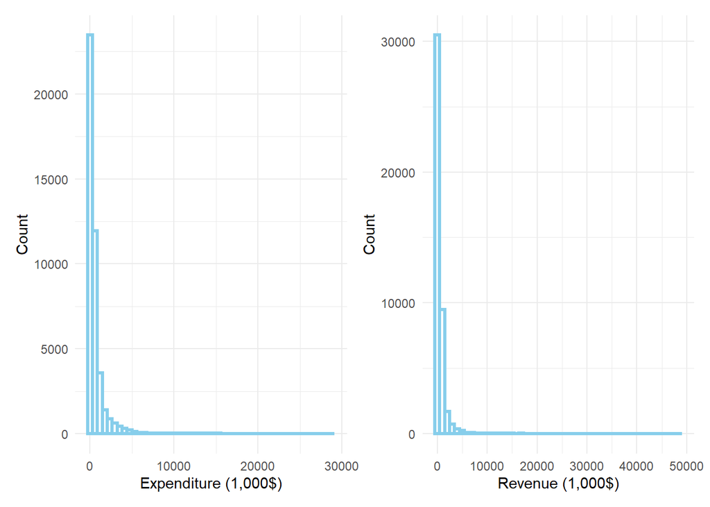

```r
library(patchwork)

sports <- sports %>% mutate(total_exp_menwomen = total_exp_menwomen/1000,
                            exp_men = exp_men/1000,
                            exp_women = exp_women/1000,
                            total_rev_menwomen = total_rev_menwomen/1000,
                            rev_men = rev_men/1000,
                            rev_women = rev_women/1000)

g_exp <- ggplot(data = sports, aes(x = total_exp_menwomen)) +
  geom_histogram(color = "skyblue", fill = "white", lwd = 1.1, bins = 50) +
  xlab("Expenditure (1,000$)") + ylab("Count") +
    theme_minimal()

g_rev <- ggplot(data = sports, aes(x = total_rev_menwomen)) +
  geom_histogram(color = "skyblue", fill = "white", lwd = 1.1, bins = 50) +
  xlab("Revenue (1,000$)") + ylab("Count") +
    theme_minimal()

g_exp + g_rev
```

These distributions are skewed, and have a long right tail.

**For code**

5 points: Creates correct histograms using ggplot() and uses right parameters for labels and bins

3 points: Creates correct histograms but doesn’t have right labels

0 points: Any other case

**For interpretation**

2 points: Mentions the plot is skewed to the right/ long right tail

1 point: Only describes that doesn’t look normal

0 points: Any other case

**5) Now transform the variables into logarithms and create the same plots. What can you say now about these graphs? (1 sentence)** *(5 points)*

Answer:

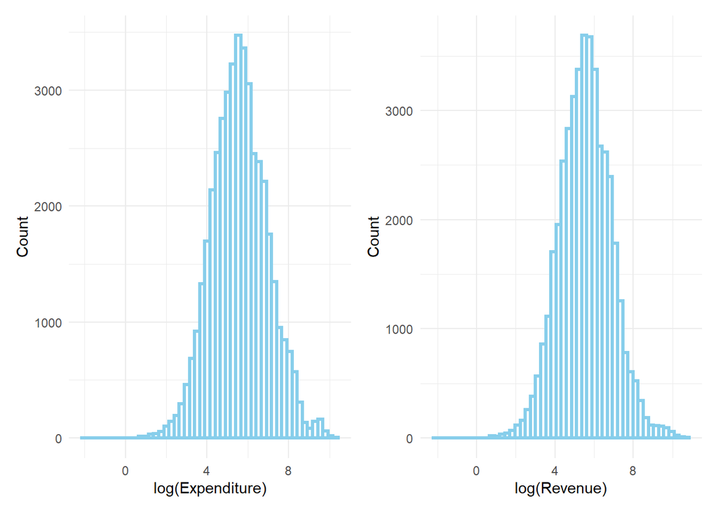

```r
sports <- sports %>% mutate(log_total_exp = log(total_exp_menwomen),
                            log_total_rev = log(total_rev_menwomen))

g_exp <- ggplot(data = sports, aes(x = log_total_exp)) +
  geom_histogram(color = "skyblue", fill = "white", lwd = 1.1, bins = 50) +
  xlab("log(Expenditure)") + ylab("Count") +
    theme_minimal()

g_rev <- ggplot(data = sports, aes(x = log_total_rev)) +
  geom_histogram(color = "skyblue", fill = "white", lwd = 1.1, bins = 50) +
  xlab("log(Revenue)") + ylab("Count") +
    theme_minimal()

g_exp + g_rev
```

By transforming expenditure and revenue with log, we can see that now they look normally distributed.

**For code**

4 points: Transforms variables correctly, creates correct histograms using ggplot(), and uses right parameters for labels and bins

3 points: Transforms variables correctly, creates correct histograms using ggplot(), but incorrect labels

2 points: Creates correct histograms, including correct labels, but incorrect log transformation

0 points: Any other case

**For interpretation**

1 point: Mentions the plots look normally distributed

0 points: Any other case

**6) Using the previously cleaned data, fit the following model:**
$$\log(TotalRevenue) = \beta_0 + \beta_1\log(TotalExpenditure) + \beta_2 Year + \varepsilon$$
**Fit the regression, show your results, and interpret $\hat{\beta}_1$** *(8 points)*

Answer:

```r
lm1 <- lm(log_total_rev ~ log_total_exp + year, data = sports)

summary(lm1)
```

```
##
## Call:
## lm(formula = log_total_rev ~ log_total_exp + year, data = sports)
##
## Residuals:
##     Min      1Q  Median      3Q     Max
## -7.3787 -0.0247  0.0441  0.1102  4.7566
##
## Coefficients:
##                 Estimate Std. Error t value            Pr(>|t|)
## (Intercept)    1.4808235  2.5249638   0.586               0.558
## log_total_exp  0.9331138  0.0013000 717.764 <0.0000000000000002 ***
## year          -0.0005673  0.0012519  -0.453               0.650
## ---
## Signif. codes:  0 '***' 0.001 '**' 0.01 '*' 0.05 '.' 0.1 ' ' 1
##
## Residual standard error: 0.3688 on 43611 degrees of freedom
## Multiple R-squared:  0.922,  Adjusted R-squared:  0.922
## F-statistic: 2.578e+05 on 2 and 43611 DF,  p-value: < 0.00000000000000022
```

Because both $x$ and $y$ are in $\log()$, we can interpret this as a percentage change. Then, an increase in 1% of total expenditures is associated with an average increase of 0.93% in total revenue, holding year constant, which is statistically significant at a 1% level.

**For code**

3 points: Runs a linear model with all correct variables

2 points: Forgets either revenue or expenditure in log OR doesn’t add year

1 point: Forgets either revenue and expenditure in log AND doesn’t add year/ forget all logs

**For interpretation**

5 points: Correct interpretation (uses the right words and percentage change)

4 points: Overall correct, but it’s missing either “On average” (“mean” or “expected” will also be accepted) or “holding year constant”

3 points: Missing both “on average” and “holding year constant”

2 points: Correct wording, but doesn’t interpret percentage change correctly (change of 1% in X is associated to change in β1% in Y)

0 points: Any other case.

## College-level data

Now that we have analyzed some general associations, let’s look at whether the association between revenue and expenditure is different for men and women’s sports.

For this, we will use a transformation of the previous dataset, where we will append data for men and women separately at the institution level to make the analysis easier. You can find the new dataset here:

```r
sports_mw <- read.csv("https://raw.githubusercontent.com/maibennett/sta235/main/exampleSite/content/Assignments/Homework/HW1/data/sports_mw.csv")
```

In `sports_mw`, we have the same data as before, but at the institution-year-gender level:

| variable | class | description |
| --- | --- | --- |
| unitid | integer | School ID |
| year | integer | year, which is year: year + 1, eg 2015 is 2015 to 2016 |
| women | integer | 1: data refers to women sports, and 0: data refers to male sports |
| revenue | double | Total revenue for all sports at the unitid-year-women level, measured in 1,000 USD |
| expenditure | double | Total expenditure for all sports at the unitid-year-women level, measured in 1,000 USD |
| enrollment | double | Enrollment at the unitid-year-women level |
| partic | double | Total participation in sports at the unitid-year-women level |

This means that for each year, a specific school (let’s say, UT), will have two observations: One for women (`women==1`) and one for men (`women==0`). You can see the structure in the following example:

[figure not shown]

**7) Using the dataset `sports_mw`, fit the following regression:** *(12 points)*

$$\begin{eqnarray*}
\log(Revenue) = &\beta_0& + \beta_1Participation + \beta_2Enrollment + \beta_3\log(Expenditure) + \\&\beta_4&Women + \beta_5log(Expenditure)\times Women+ \varepsilon
\end{eqnarray*}$$
**What is the association between revenue and expenditure for men’s sports? and for women’s? Are they significantly different? Explain**

Answer:

```r
sports_mw <- sports_mw %>% mutate(log_revenue = log(revenue),
                                  log_expenditure = log(expenditure))

lm2 <- lm(log_revenue ~ partic + enrollment + log_expenditure*women, data = sports_mw)

summary(lm2)
```

```
##
## Call:
## lm(formula = log_revenue ~ partic + enrollment + log_expenditure *
##     women, data = sports_mw)
##
## Residuals:
##     Min      1Q  Median      3Q     Max
## -4.2690 -0.0454 -0.0022  0.0593  3.6683
##
## Coefficients:
##                            Estimate    Std. Error t value             Pr(>|t|)
## (Intercept)           -0.0633060677  0.0111422746  -5.682         0.0000000135
## partic                 0.0000534205  0.0000293198   1.822               0.0685
## enrollment            -0.0000249560  0.0000006598 -37.825 < 0.0000000000000002
## log_expenditure        1.0192250723  0.0019718041 516.900 < 0.0000000000000002
## women                  0.3543336128  0.0144792828  24.472 < 0.0000000000000002
## log_expenditure:women -0.0630469214  0.0022284949 -28.291 < 0.0000000000000002
##
## (Intercept)           ***
## partic                .
## enrollment            ***
## log_expenditure       ***
## women                 ***
## log_expenditure:women ***
## ---
## Signif. codes:  0 '***' 0.001 '**' 0.01 '*' 0.05 '.' 0.1 ' ' 1
##
## Residual standard error: 0.2345 on 19846 degrees of freedom
## Multiple R-squared:  0.9744, Adjusted R-squared:  0.9744
## F-statistic: 1.512e+05 on 5 and 19846 DF,  p-value: < 0.00000000000000022
```

**For code**

2 points: Regression is correct

1 point: Code has small issues

0 points: Any other case

- For a 1% increase in expenditure, male sports increase their revenue, on average, by 1.02%, holding other variables constant.

3 points: Point estimate is correct

0 points: Point estimate is not correct

- For a 1% increase in expenditure, female sports increase their revenue, on average, by 0.956%, holding other variables constant.

**For interpretation**

5 points: Number is correct and interpretation is correct (e.g. uses “on average”/“expected”, hold variables constant, % change)

3 points: Either the interpretation or the point estimate is incorrect.

0 points: Both the interpretation and point estimate is incorrect.

2 points: Identifies the difference is statistically significant.

0 points: Any other case.

# Task 3 - All about that real estate bubble (45 points)

We will be using a sample of the data collected by [Yung et. al. (2021)](https://github.com/kaiyungtan/Real-Estate-data-analysis) for housing prices and characteristics in Belgium.

```r
housing <- read.csv("https://raw.githubusercontent.com/maibennett/sta235/main/exampleSite/content/Assignments/Homework/HW1/data/housing.csv")
```

Some of the variables you will be using for the analysis:

| variable | class | description |
| --- | --- | --- |
| price | integer | Selling price (in Euros) |
| house_area | integer | Area of the unit (in sq meters) |
| number_of_rooms | integer | Number of rooms |
| swimming_pool | integer | Unit has a pool (1) or not (0) |
| construction_year | int | Year the unit was built |

**1) Create a scatter plot for price (y-axis) and area (x-axis), by type of property** (5 points)

Answer:

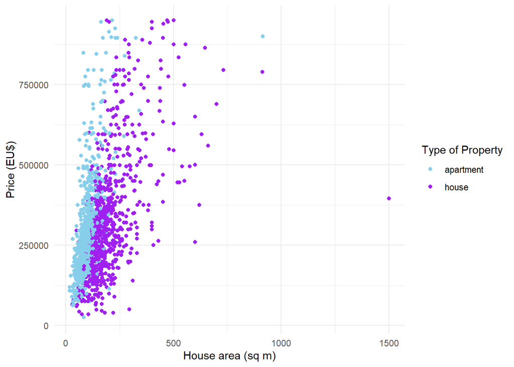

```r
ggplot(data = housing, aes(x = house_area, y = price, color = factor(type_of_property))) +
  geom_point() +
  xlab("House area (sq m)") + ylab("Price (EU$)") +
  scale_color_manual("Type of Property", values = c("skyblue", "purple")) +
  theme_minimal()
```

5 points: Code is correct (creates one plot, with distinct markers and/or colors for type of property). Labels and legend are also appropriate.

3 points: Code is correct but missing/incorrect labels or legend

2 points: Creates two plots

0 points: Any other case

**2) What is true about the previous plot:** (3 points)

**a) There is a strong, positive correlation between area and price**  
**b) The association between price and area is stronger for houses than for apartments**  
**c) Most units are under 500 sq meters**  
**d) On average, apartments are larger than houses**

Answer:

A and C

**3) Fit the following model:**
$$Price = \beta_0 + \beta_1 NumRooms + \beta_2 Area + \beta_4 Pool + \beta_5 Apartment + \varepsilon$$

**where Apartment is a variable the takes the value of 1 if the property is an apartment and 0 in another case.**

*Note: You will have to create an additional variable*

**a) What is the average price for a 350 sq m house with 3 rooms and a pool? (Round to the closest integer)** (7 points)

Answer:

```r
housing <- housing %>% mutate(apartment = ifelse(type_of_property=="apartment", 1, 0))

lm1 <- lm(price ~ number_of_rooms + house_area + swimming_pool + apartment, data = housing)

summary(lm1)
```

```
##
## Call:
## lm(formula = price ~ number_of_rooms + house_area + swimming_pool +
##     apartment, data = housing)
##
## Residuals:
##      Min       1Q   Median       3Q      Max
## -1122322   -80275   -22555    56177   625572
##
## Coefficients:
##                  Estimate Std. Error t value             Pr(>|t|)
## (Intercept)      65173.52   11882.27   5.485     0.00000004768964 ***
## number_of_rooms  27561.05    3851.41   7.156     0.00000000000124 ***
## house_area         857.85      49.32  17.393 < 0.0000000000000002 ***
## swimming_pool   132339.43   29712.42   4.454     0.00000898602883 ***
## apartment        87054.45    8238.31  10.567 < 0.0000000000000002 ***
## ---
## Signif. codes:  0 '***' 0.001 '**' 0.01 '*' 0.05 '.' 0.1 ' ' 1
##
## Residual standard error: 138200 on 1674 degrees of freedom
##   (321 observations deleted due to missingness)
## Multiple R-squared:  0.3427, Adjusted R-squared:  0.3411
## F-statistic: 218.2 on 4 and 1674 DF,  p-value: < 0.00000000000000022
```

```r
area = 350
apartment = 0
rooms = 3
pool = 1

price0 <- lm1$coefficients[1] + lm1$coefficients[2]*rooms +
  lm1$coefficients[3]*area + lm1$coefficients[4]*pool +
  lm1$coefficients[5]*apartment
```

The average price is EU$580445

**For code**

4 points: Fits the correct model, including creating the apartment variable correctly

2 points: Problem with the model OR creating the apartment variable correctly

0 points: Problems with the model AND the apartment variable.

3 points: Point estimate is correct.

0 points: Point estimate is not correct.

**b) Interpret the intercept for the previous regression. What is it capturing? Is it meaningful?** (5 points)

The intercept captures the average price for a house with no swimming pool, no rooms, and 0 sqm, which is $65,000. However, it doesn’t have a practical interpretation.

**For interpretation**

5 points: Interprets the intercept correctly and identifies that is not meaningful in practice

3 points: Interprets the intercept correctly but doesn’t identify that is not meaningful in practice/ Has minor problems interpreting the intercept, but identifies it’s not meaningful

0 points: Has problems with both the interpretation and identifying whether it’s meaningful or not.

**4) Fit the following quadratic model:** (5 points)

$$Price = \beta_0 + \beta_1 Area + \beta_2 Area^2 + \varepsilon$$

**a) What is the average increase/decrease in price for an extra sq meter for an average-sized unit? Round to the nearest integer** (10 points)  
Answer:

```r
lm2 <- lm(price ~ house_area + I(house_area^2), data = housing)

summary(lm2)
```

```
##
## Call:
## lm(formula = price ~ house_area + I(house_area^2), data = housing)
##
## Residuals:
##     Min      1Q  Median      3Q     Max
## -440567  -78668  -17301   56294  614373
##
## Coefficients:
##                    Estimate  Std. Error t value            Pr(>|t|)
## (Intercept)     116048.8746   8278.5464   14.02 <0.0000000000000002 ***
## house_area        1520.7698     65.1211   23.35 <0.0000000000000002 ***
## I(house_area^2)     -0.9110      0.0836  -10.90 <0.0000000000000002 ***
## ---
## Signif. codes:  0 '***' 0.001 '**' 0.01 '*' 0.05 '.' 0.1 ' ' 1
##
## Residual standard error: 139200 on 1676 degrees of freedom
##   (321 observations deleted due to missingness)
## Multiple R-squared:  0.3326, Adjusted R-squared:  0.3318
## F-statistic: 417.6 on 2 and 1676 DF,  p-value: < 0.00000000000000022
```

```r
area = mean(housing$house_area, na.rm = TRUE)

price1 <- lm2$coefficients[2] + 2*lm2$coefficients[3]*area
```

For an average-size unit, one sq-m increase in area is associated with an average increase of EU$1250 in price.

**For code**

5 points: Includes correct regression and shows correct calculation of the previous number (e.g. multiplying $2\hat{\beta}_2\bar{Area} + \hat{\beta}_1$)

3 points: Either regression OR calculation is not correct

1 point: Attempts something, but mainly not correct.

5 points: Point estimate is correct.

0 points: Point estimate is not correct.

**b) What is the average increase/decrease in price for an extra sq meter for an 600 sq-m unit?** (3 points)  
Answer:

```r
area = 600

price2 <- lm2$coefficients[2] + 2*lm2$coefficients[3]*area
```

For an 600-sqm unit, one sq-m increase in area is associated with an average increase of EU$428 in price.

3 points: Point estimate is correct.

0 points: Point estimate is not correct.

**c) Looking at your previous results, which of the following statements is/are TRUE?** (3 points)

**a) There is no evidence of a quadratic relationship between area and price**  
**b) There is evidence of a quadratic relationship between area and price**  
**c) There are diminishing returns to an extra sq meter**  
**d) There are increasing returns to an extra sq meter**

Answer: B and C

**5) We have a hypothesis that an additional sq meter has a larger association in price for an apartment compared to a house. For that, we will fit the following regression:** (2 points)
$$Price = \beta_0 + \beta_1 Area + \beta_2 Apartment + \beta_3 Apartment \times Area + \varepsilon$$
**a) Insert your code for fitting the model:**

```r
lm3 <- lm(price ~ house_area*apartment, data = housing)

summary(lm3)
```

```
##
## Call:
## lm(formula = price ~ house_area * apartment, data = housing)
##
## Residuals:
##      Min       1Q   Median       3Q      Max
## -1148591   -79113   -21836    49851   626799
##
## Coefficients:
##                       Estimate Std. Error t value             Pr(>|t|)
## (Intercept)          147263.57    9735.45  15.127 < 0.0000000000000002 ***
## house_area              930.88      42.49  21.908 < 0.0000000000000002 ***
## apartment            -49618.94   14617.67  -3.394             0.000704 ***
## house_area:apartment   1028.60     106.92   9.620 < 0.0000000000000002 ***
## ---
## Signif. codes:  0 '***' 0.001 '**' 0.01 '*' 0.05 '.' 0.1 ' ' 1
##
## Residual standard error: 137100 on 1675 degrees of freedom
##   (321 observations deleted due to missingness)
## Multiple R-squared:  0.3526, Adjusted R-squared:  0.3514
## F-statistic:   304 on 3 and 1675 DF,  p-value: < 0.00000000000000022
```

**For code**

2 points: Code is correct

1 point: Code has a small error

0 points: Any other case

**b) What is the average return in price for an extra sq meter in a house?** (2 points)  
For a house, a one sqm increase in area is associated with an average EU$931 increase in price.

2 points: Point estimate is correct.

0 points: Point estimate is not correct.

**c) What is the average return in price for an extra sq meter in an apartment?** (3 points)  
For an apartment, a one sqm increase in area is associated with a EU$1959 increase in price, on average.

3 points: Point estimate is correct.

0 points: Point estimate is not correct.

**b) Is the difference statistically significant?** (1 point)

**a) Yes**  
**b) No**  
**c) Can’t tell**

Answer: A

**c) Does this support our original hypothesis?** (1 point)

**a) Yes**  
**b) No**

Answer: Yes